# CMSC320_Final_Project (1)

**US Obesity Rate Patterns**

Fall 2024 Data Science Project

Isaac Plowman, Praharsh Nanduri, Justin Nguyen, Kevin Ferry, Charles Kim

Contributions:

A: Project idea

Isaac Plowman

B: Dataset Curation and Preprocessing

Isaac Plowman

C: Data Exploration and Summary Statistics

D: ML Algorithm Design/Development

E: ML Algorithm Training and Test Data Analysis

F: Visualization, Result Analysis, Conclusion

G: Final Tutorial Report Creation

H: Additional (not listed above)

**Introduction**

Our topic is focused on obesity rates and patterns in the US. Specifically, our project involves in looking at numerous factors like physical activity, geographic location, income, and education for correlation with obesity. We can also use the chosen data for predicting the percentage of a certain specification (e.g. percentage of adults who engage in no leisure-time physical activity) based on the features of a geographical area.

Unfortuantely, obesity is a highly prevalent disease that has been affecting people negatively globally. Data from 2023 shows that in 23 U.S. states, one in five adults in the U.S. has obesity (CDC data). With growing fast-food and snacking markets and an increase in prices of healthy foods, people are more influenced to buy less healthy food alternatives for a cheap price. Additionally, obesity is linked to many chronic conditions like diabetes, heart disease, and certain cancers. We examine these datasets for predicting healthcare needs, and for the assistance of creating nutritional guidelines and policies to mitigate the growth of obesity. Additionally, we can locate disparities in obesity rates and the connections between obesity and certain economic, racial, and geographical groups. These datasets allow us to examine environmental influences on obesity and understand the connection between fast food availability and health outcomes. Understanding this information provides knowledge on populations that are at risk, which determines the amount of resources to allocate and where to allocate them.

**Data Curation**

For our project, we analyzed three different datasets from two different websites. The links to where we gathered data include the following:

**Nutrition_Activity_Obesity From Data.gov:**

https://catalog.data.gov/dataset/nutrition-physical-activity-and-obesity-behavioral-risk-factor-surveillance-system

**FastFoodRestaurants and Datafiniti_Fast_Food_Restaurants From Kaggle.com:**

https://www.kaggle.com/datasets/imtkaggleteam/fast-food-restaurants-across-america/data?select=FastFoodRestaurants.csv

"Nutrition_Activity_Obesity" refers to the dataset that includes different topics or questions and their corresponding percentage. The "FastFoodRestaurants" datasets include the locations of fast food restaurants across the US. These datasets will be used for analysis and pattern prediction, but before that we must process and clean their data.

First we must create the data frames using the csv files. Down below we display the dataframes.

```python
import pandas as pd
import matplotlib.pyplot as plt

ffr_df = pd.read_csv('FastFoodRestaurants.csv')
obesity_df = pd.read_csv('Nutrition_Activity_Obesity.csv')
Datafini_ffr_df = pd.read_csv('Datafiniti_Fast_Food_Restaurants.csv')

display(obesity_df)
display(ffr_df)
display(Datafini_ffr_df)
```

|  | YearStart | YearEnd | LocationAbbr | LocationDesc | Datasource | Class | Topic | Question | Data_Value_Unit | Data_Value_Type | ... | GeoLocation | ClassID | TopicID | QuestionID | DataValueTypeID | LocationID | StratificationCategory1 | Stratification1 | StratificationCategoryId1 | StratificationID1 |
| --- | --- | --- | --- | --- | --- | --- | --- | --- | --- | --- | --- | --- | --- | --- | --- | --- | --- | --- | --- | --- | --- |
| 0 | 2020 | 2020 | US | National | Behavioral Risk Factor Surveillance System | Physical Activity | Physical Activity - Behavior | Percent of adults who engage in no leisure-tim... | NaN | Value | ... | NaN | PA | PA1 | Q047 | VALUE | 59 | Race/Ethnicity | Hispanic | RACE | RACEHIS |
| 1 | 2014 | 2014 | GU | Guam | Behavioral Risk Factor Surveillance System | Obesity / Weight Status | Obesity / Weight Status | Percent of adults aged 18 years and older who ... | NaN | Value | ... | (13.444304, 144.793731) | OWS | OWS1 | Q036 | VALUE | 66 | Education | High school graduate | EDU | EDUHSGRAD |
| 2 | 2013 | 2013 | US | National | Behavioral Risk Factor Surveillance System | Obesity / Weight Status | Obesity / Weight Status | Percent of adults aged 18 years and older who ... | NaN | Value | ... | NaN | OWS | OWS1 | Q036 | VALUE | 59 | Income | $50,000 - $74,999 | INC | INC5075 |
| 3 | 2013 | 2013 | US | National | Behavioral Risk Factor Surveillance System | Obesity / Weight Status | Obesity / Weight Status | Percent of adults aged 18 years and older who ... | NaN | Value | ... | NaN | OWS | OWS1 | Q037 | VALUE | 59 | Income | Data not reported | INC | INCNR |
| 4 | 2015 | 2015 | US | National | Behavioral Risk Factor Surveillance System | Physical Activity | Physical Activity - Behavior | Percent of adults who achieve at least 300 min... | NaN | Value | ... | NaN | PA | PA1 | Q045 | VALUE | 59 | Income | Less than $15,000 | INC | INCLESS15 |
| ... | ... | ... | ... | ... | ... | ... | ... | ... | ... | ... | ... | ... | ... | ... | ... | ... | ... | ... | ... | ... | ... |
| 93244 | 2022 | 2022 | WY | Wyoming | BRFSS | Obesity / Weight Status | Obesity / Weight Status | Percent of adults aged 18 years and older who ... | NaN | Value | ... | (43.23554134300048, -108.10983035299967) | OWS | OWS1 | Q037 | VALUE | 56 | Income | Less than $15,000 | INC | INCLESS15 |
| 93245 | 2022 | 2022 | WY | Wyoming | BRFSS | Physical Activity | Physical Activity - Behavior | Percent of adults who engage in no leisure-tim... | NaN | Value | ... | (43.23554134300048, -108.10983035299967) | PA | PA1 | Q047 | VALUE | 56 | Education | Less than high school | EDU | EDUHS |
| 93246 | 2022 | 2022 | WY | Wyoming | BRFSS | Obesity / Weight Status | Obesity / Weight Status | Percent of adults aged 18 years and older who ... | NaN | Value | ... | (43.23554134300048, -108.10983035299967) | OWS | OWS1 | Q036 | VALUE | 56 | Age (years) | 35 - 44 | AGEYR | AGEYR3544 |
| 93247 | 2022 | 2022 | WY | Wyoming | BRFSS | Obesity / Weight Status | Obesity / Weight Status | Percent of adults aged 18 years and older who ... | NaN | Value | ... | (43.23554134300048, -108.10983035299967) | OWS | OWS1 | Q037 | VALUE | 56 | Income | $35,000 - $49,999 | INC | INC3550 |
| 93248 | 2022 | 2022 | WY | Wyoming | BRFSS | Obesity / Weight Status | Obesity / Weight Status | Percent of adults aged 18 years and older who ... | NaN | Value | ... | (43.23554134300048, -108.10983035299967) | OWS | OWS1 | Q036 | VALUE | 56 | Education | Less than high school | EDU | EDUHS |

93249 rows × 33 columns

|  | address | city | country | keys | latitude | longitude | name | postalCode | province | websites |
| --- | --- | --- | --- | --- | --- | --- | --- | --- | --- | --- |
| 0 | 324 Main St | Massena | US | us/ny/massena/324mainst/-1161002137 | 44.921300 | -74.890210 | McDonald's | 13662 | NY | http://mcdonalds.com,http://www.mcdonalds.com/... |
| 1 | 530 Clinton Ave | Washington Court House | US | us/oh/washingtoncourthouse/530clintonave/-7914... | 39.532550 | -83.445260 | Wendy's | 43160 | OH | http://www.wendys.com |
| 2 | 408 Market Square Dr | Maysville | US | us/ky/maysville/408marketsquaredr/1051460804 | 38.627360 | -83.791410 | Frisch's Big Boy | 41056 | KY | http://www.frischs.com,https://www.frischs.com... |
| 3 | 6098 State Highway 37 | Massena | US | us/ny/massena/6098statehighway37/-1161002137 | 44.950080 | -74.845530 | McDonald's | 13662 | NY | http://mcdonalds.com,http://www.mcdonalds.com/... |
| 4 | 139 Columbus Rd | Athens | US | us/oh/athens/139columbusrd/990890980 | 39.351550 | -82.097280 | OMG! Rotisserie | 45701 | OH | http://www.omgrotisserie.com,http://omgrotisse... |
| ... | ... | ... | ... | ... | ... | ... | ... | ... | ... | ... |
| 9995 | 3013 Peach Orchard Rd | Augusta | US | us/ga/augusta/3013peachorchardrd/-791445730 | 33.415257 | -82.024531 | Wendy's | 30906 | GA | http://www.wendys.com,http://wendys.com |
| 9996 | 678 Northwest Hwy | Cary | US | us/il/cary/678northwesthwy/787691191 | 42.217300 | -88.255800 | Lee's Oriental Martial Arts | 60013 | IL | http://www.mcdonalds.com |
| 9997 | 1708 Main St | Longmont | US | us/co/longmont/1708mainst/-448666054 | 40.189190 | -105.101720 | Five Guys | 80501 | CO | http://fiveguys.com |
| 9998 | 67740 Highway 111 | Cathedral City | US | us/ca/cathedralcity/67740highway111/-981164808 | 33.788640 | -116.482150 | El Pollo Loco | 92234 | CA | http://www.elpolloloco.com,http://elpolloloco.com |
| 9999 | 5701 E La Palma Ave | Anaheim | US | us/ca/anaheim/5701elapalmaave/554191587 | 33.860074 | -117.789762 | Carl's Jr. | 92807 | CA | http://www.carlsjr.com |

10000 rows × 10 columns

|  | id | dateAdded | dateUpdated | address | categories | city | country | keys | latitude | longitude | name | postalCode | province | sourceURLs | websites |
| --- | --- | --- | --- | --- | --- | --- | --- | --- | --- | --- | --- | --- | --- | --- | --- |
| 0 | AVwcmSyZIN2L1WUfmxyw | 2015-10-19T23:47:58Z | 2018-06-26T03:00:14Z | 800 N Canal Blvd | American Restaurant and Fast Food Restaurant | Thibodaux | US | us/la/thibodaux/800ncanalblvd/1780593795 | 29.814697 | -90.814742 | SONIC Drive In | 70301 | LA | https://foursquare.com/v/sonic-drive-in/4b7361... | https://locations.sonicdrivein.com/la/thibodau... |
| 1 | AVwcmSyZIN2L1WUfmxyw | 2015-10-19T23:47:58Z | 2018-06-26T03:00:14Z | 800 N Canal Blvd | Fast Food Restaurants | Thibodaux | US | us/la/thibodaux/800ncanalblvd/1780593795 | 29.814697 | -90.814742 | SONIC Drive In | 70301 | LA | https://foursquare.com/v/sonic-drive-in/4b7361... | https://locations.sonicdrivein.com/la/thibodau... |
| 2 | AVwcopQoByjofQCxgfVa | 2016-03-29T05:06:36Z | 2018-06-26T02:59:52Z | 206 Wears Valley Rd | Fast Food Restaurant | Pigeon Forge | US | us/tn/pigeonforge/206wearsvalleyrd/-864103396 | 35.803788 | -83.580553 | Taco Bell | 37863 | TN | https://www.yellowpages.com/pigeon-forge-tn/mi... | http://www.tacobell.com,https://locations.taco... |
| 3 | AVweXN5RByjofQCxxilK | 2017-01-03T07:46:11Z | 2018-06-26T02:59:51Z | 3652 Parkway | Fast Food | Pigeon Forge | US | us/tn/pigeonforge/3652parkway/93075755 | 35.782339 | -83.551408 | Arby's | 37863 | TN | http://www.yellowbook.com/profile/arbys_163389... | http://www.arbys.com,https://locations.arbys.c... |
| 4 | AWQ6MUvo3-Khe5l_j3SG | 2018-06-26T02:59:43Z | 2018-06-26T02:59:43Z | 2118 Mt Zion Parkway | Fast Food Restaurant | Morrow | US | us/ga/morrow/2118mtzionparkway/1305117222 | 33.562738 | -84.321143 | Steak 'n Shake | 30260 | GA | https://foursquare.com/v/steak-n-shake/4bcf77a... | http://www.steaknshake.com/locations/23851-ste... |
| ... | ... | ... | ... | ... | ... | ... | ... | ... | ... | ... | ... | ... | ... | ... | ... |
| 9995 | AV12gJwna4HuVbed9Ayg | 2017-07-24T21:28:46Z | 2018-04-07T13:19:06Z | 3460 Robinhood Rd | Fast Food Restaurants | Winston-Salem | US | us/nc/winston-salem/3460robinhoodrd/-66712705 | 36.117563 | -80.316553 | Pizza Hut | 27106 | NC | https://www.allmenus.com/nc/winston-salem/7341... | http://www.pizzahut.com |
| 9996 | AV12gJxKIxWefVJwhpzS | 2017-07-24T21:28:46Z | 2018-04-07T13:19:05Z | 3069 Kernersville Rd | Fast Food Restaurants | Winston-Salem | US | us/nc/winston-salem/3069kernersvillerd/-66712705 | 36.077718 | -80.176748 | Pizza Hut | 27107 | NC | https://www.allmenus.com/nc/winston-salem/7340... | http://www.pizzahut.com |
| 9997 | AVwdJMdSByjofQCxl8Vr | 2015-10-24T00:17:32Z | 2018-04-07T13:19:05Z | 838 S Main St | Fast Food Restaurants | Kernersville | US | us/nc/kernersville/838smainst/-66712705 | 36.111015 | -80.089165 | Pizza Hut | 27284 | NC | https://www.allmenus.com/nc/kernersville/73400... | http://www.pizzahut.com |
| 9998 | AVwdl2cykufWRAb57ZPs | 2016-04-05T02:59:45Z | 2018-04-07T13:19:05Z | 1702 Glendale Dr SW | Fast Food Restaurants | Wilson | US | us/nc/wilson/1702glendaledrsw/-66712705 | 35.719981 | -77.945795 | Pizza Hut | 27893 | NC | https://www.allmenus.com/nc/wilson/73403-pizza... | http://www.pizzahut.com |
| 9999 | AVwdecWKIN2L1WUfwMWU | 2016-11-08T02:26:32Z | 2018-04-07T13:19:05Z | 1405 W Broad St | Fast Food Restaurants | Elizabethtown | US | us/nc/elizabethtown/1405wbroadst/-66712705 | 34.632778 | -78.624615 | Pizza Hut | 28337 | NC | https://www.allmenus.com/nc/elizabethtown/7339... | http://www.pizzahut.com,http://api.citygridmed... |

10000 rows × 15 columns

Now, we can start cleaning and exploring the data of our dataframes. First, let's clean and examine obesity_df. It seems that all the values in the column, "Data_Value_Unit," are NaN, so let's check the count of non NaN values using the count function.

```python
print("Data_Value_Unit # of Non NaN:", obesity_df['Data_Value_Unit'].count()) # Count the number of rows
```

```
Data_Value_Unit # of Non NaN: 0
```

Seeing that this column is entirely NaN, we can drop it.

```python
obesity_df = obesity_df.drop(columns=['Data_Value_Unit'])
```

It's also clear that the values of the the column "Data_Value_Type" are useless because all the values seem to have "Value" as their literal. We can test to see if all the values in this column are "Value" by using the unique method.

```python
obesity_df['Data_Value_Type'].unique()
```

```
array(['Value'], dtype=object)
```

We see that the only unique value is "Value," so we can also drop those columns.

```python
obesity_df = obesity_df.drop(columns=['Data_Value_Type'])
display(obesity_df)
```

|  | YearStart | YearEnd | LocationAbbr | LocationDesc | Datasource | Class | Topic | Question | Data_Value | Data_Value_Alt | ... | GeoLocation | ClassID | TopicID | QuestionID | DataValueTypeID | LocationID | StratificationCategory1 | Stratification1 | StratificationCategoryId1 | StratificationID1 |
| --- | --- | --- | --- | --- | --- | --- | --- | --- | --- | --- | --- | --- | --- | --- | --- | --- | --- | --- | --- | --- | --- |
| 0 | 2020 | 2020 | US | National | Behavioral Risk Factor Surveillance System | Physical Activity | Physical Activity - Behavior | Percent of adults who engage in no leisure-tim... | 30.6 | 30.6 | ... | NaN | PA | PA1 | Q047 | VALUE | 59 | Race/Ethnicity | Hispanic | RACE | RACEHIS |
| 1 | 2014 | 2014 | GU | Guam | Behavioral Risk Factor Surveillance System | Obesity / Weight Status | Obesity / Weight Status | Percent of adults aged 18 years and older who ... | 29.3 | 29.3 | ... | (13.444304, 144.793731) | OWS | OWS1 | Q036 | VALUE | 66 | Education | High school graduate | EDU | EDUHSGRAD |
| 2 | 2013 | 2013 | US | National | Behavioral Risk Factor Surveillance System | Obesity / Weight Status | Obesity / Weight Status | Percent of adults aged 18 years and older who ... | 28.8 | 28.8 | ... | NaN | OWS | OWS1 | Q036 | VALUE | 59 | Income | $50,000 - $74,999 | INC | INC5075 |
| 3 | 2013 | 2013 | US | National | Behavioral Risk Factor Surveillance System | Obesity / Weight Status | Obesity / Weight Status | Percent of adults aged 18 years and older who ... | 32.7 | 32.7 | ... | NaN | OWS | OWS1 | Q037 | VALUE | 59 | Income | Data not reported | INC | INCNR |
| 4 | 2015 | 2015 | US | National | Behavioral Risk Factor Surveillance System | Physical Activity | Physical Activity - Behavior | Percent of adults who achieve at least 300 min... | 26.6 | 26.6 | ... | NaN | PA | PA1 | Q045 | VALUE | 59 | Income | Less than $15,000 | INC | INCLESS15 |
| ... | ... | ... | ... | ... | ... | ... | ... | ... | ... | ... | ... | ... | ... | ... | ... | ... | ... | ... | ... | ... | ... |
| 93244 | 2022 | 2022 | WY | Wyoming | BRFSS | Obesity / Weight Status | Obesity / Weight Status | Percent of adults aged 18 years and older who ... | 24.5 | 24.5 | ... | (43.23554134300048, -108.10983035299967) | OWS | OWS1 | Q037 | VALUE | 56 | Income | Less than $15,000 | INC | INCLESS15 |
| 93245 | 2022 | 2022 | WY | Wyoming | BRFSS | Physical Activity | Physical Activity - Behavior | Percent of adults who engage in no leisure-tim... | 36.0 | 36.0 | ... | (43.23554134300048, -108.10983035299967) | PA | PA1 | Q047 | VALUE | 56 | Education | Less than high school | EDU | EDUHS |
| 93246 | 2022 | 2022 | WY | Wyoming | BRFSS | Obesity / Weight Status | Obesity / Weight Status | Percent of adults aged 18 years and older who ... | 35.2 | 35.2 | ... | (43.23554134300048, -108.10983035299967) | OWS | OWS1 | Q036 | VALUE | 56 | Age (years) | 35 - 44 | AGEYR | AGEYR3544 |
| 93247 | 2022 | 2022 | WY | Wyoming | BRFSS | Obesity / Weight Status | Obesity / Weight Status | Percent of adults aged 18 years and older who ... | 35.3 | 35.3 | ... | (43.23554134300048, -108.10983035299967) | OWS | OWS1 | Q037 | VALUE | 56 | Income | $35,000 - $49,999 | INC | INC3550 |
| 93248 | 2022 | 2022 | WY | Wyoming | BRFSS | Obesity / Weight Status | Obesity / Weight Status | Percent of adults aged 18 years and older who ... | 41.0 | 41.0 | ... | (43.23554134300048, -108.10983035299967) | OWS | OWS1 | Q036 | VALUE | 56 | Education | Less than high school | EDU | EDUHS |

93249 rows × 31 columns

We can also get rid of some of the ID columns and the Data_Value_Alt column since they're described by other columns. This helps the data frame become more readable. We can see if Data_Value_Alt is needed by comparing it to the Data Value column.

```python
obesity_df['Data_Value_Alt'].equals(obesity_df['Data_Value'])
```

```
True
```

Since Data_Value_Alt is identical to Data Value we can drop it along with the ID columns.

```python
obesity_df = obesity_df.drop(columns=['Data_Value_Alt','QuestionID', 'DataValueTypeID', 'ClassID', 'TopicID', 'LocationID', 'StratificationCategoryId1', 'StratificationID1'])
obesity_df
```

|  | YearStart | YearEnd | LocationAbbr | LocationDesc | Datasource | Class | Topic | Question | Data_Value | Data_Value_Footnote_Symbol | ... | Sample_Size | Total | Age(years) | Education | Gender | Income | Race/Ethnicity | GeoLocation | StratificationCategory1 | Stratification1 |
| --- | --- | --- | --- | --- | --- | --- | --- | --- | --- | --- | --- | --- | --- | --- | --- | --- | --- | --- | --- | --- | --- |
| 0 | 2020 | 2020 | US | National | Behavioral Risk Factor Surveillance System | Physical Activity | Physical Activity - Behavior | Percent of adults who engage in no leisure-tim... | 30.6 | NaN | ... | 31255.0 | NaN | NaN | NaN | NaN | NaN | Hispanic | NaN | Race/Ethnicity | Hispanic |
| 1 | 2014 | 2014 | GU | Guam | Behavioral Risk Factor Surveillance System | Obesity / Weight Status | Obesity / Weight Status | Percent of adults aged 18 years and older who ... | 29.3 | NaN | ... | 842.0 | NaN | NaN | High school graduate | NaN | NaN | NaN | (13.444304, 144.793731) | Education | High school graduate |
| 2 | 2013 | 2013 | US | National | Behavioral Risk Factor Surveillance System | Obesity / Weight Status | Obesity / Weight Status | Percent of adults aged 18 years and older who ... | 28.8 | NaN | ... | 62562.0 | NaN | NaN | NaN | NaN | $50,000 - $74,999 | NaN | NaN | Income | $50,000 - $74,999 |
| 3 | 2013 | 2013 | US | National | Behavioral Risk Factor Surveillance System | Obesity / Weight Status | Obesity / Weight Status | Percent of adults aged 18 years and older who ... | 32.7 | NaN | ... | 60069.0 | NaN | NaN | NaN | NaN | Data not reported | NaN | NaN | Income | Data not reported |
| 4 | 2015 | 2015 | US | National | Behavioral Risk Factor Surveillance System | Physical Activity | Physical Activity - Behavior | Percent of adults who achieve at least 300 min... | 26.6 | NaN | ... | 30904.0 | NaN | NaN | NaN | NaN | Less than $15,000 | NaN | NaN | Income | Less than $15,000 |
| ... | ... | ... | ... | ... | ... | ... | ... | ... | ... | ... | ... | ... | ... | ... | ... | ... | ... | ... | ... | ... | ... |
| 93244 | 2022 | 2022 | WY | Wyoming | BRFSS | Obesity / Weight Status | Obesity / Weight Status | Percent of adults aged 18 years and older who ... | 24.5 | NaN | ... | 111.0 | NaN | NaN | NaN | NaN | Less than $15,000 | NaN | (43.23554134300048, -108.10983035299967) | Income | Less than $15,000 |
| 93245 | 2022 | 2022 | WY | Wyoming | BRFSS | Physical Activity | Physical Activity - Behavior | Percent of adults who engage in no leisure-tim... | 36.0 | NaN | ... | 159.0 | NaN | NaN | Less than high school | NaN | NaN | NaN | (43.23554134300048, -108.10983035299967) | Education | Less than high school |
| 93246 | 2022 | 2022 | WY | Wyoming | BRFSS | Obesity / Weight Status | Obesity / Weight Status | Percent of adults aged 18 years and older who ... | 35.2 | NaN | ... | 450.0 | NaN | 35 - 44 | NaN | NaN | NaN | NaN | (43.23554134300048, -108.10983035299967) | Age (years) | 35 - 44 |
| 93247 | 2022 | 2022 | WY | Wyoming | BRFSS | Obesity / Weight Status | Obesity / Weight Status | Percent of adults aged 18 years and older who ... | 35.3 | NaN | ... | 512.0 | NaN | NaN | NaN | NaN | $35,000 - $49,999 | NaN | (43.23554134300048, -108.10983035299967) | Income | $35,000 - $49,999 |
| 93248 | 2022 | 2022 | WY | Wyoming | BRFSS | Obesity / Weight Status | Obesity / Weight Status | Percent of adults aged 18 years and older who ... | 41.0 | NaN | ... | 146.0 | NaN | NaN | Less than high school | NaN | NaN | NaN | (43.23554134300048, -108.10983035299967) | Education | Less than high school |

93249 rows × 23 columns

We can also see the data value footnote columns in case they are of use

```python
obesity_df['Data_Value_Footnote_Symbol'].unique()
```

```
array([nan, '~'], dtype=object)
```

```python
obesity_df['Data_Value_Footnote'].unique()
```

```
array([nan, 'Data not available because sample size is insufficient.'],
      dtype=object)
```

These basically describe the missing data which can already be seen by using the dropna method.

```python
obesity_df = obesity_df.drop(columns=['Data_Value_Footnote_Symbol', 'Data_Value_Footnote'])
obesity_df
```

|  | YearStart | YearEnd | LocationAbbr | LocationDesc | Datasource | Class | Topic | Question | Data_Value | Low_Confidence_Limit | ... | Sample_Size | Total | Age(years) | Education | Gender | Income | Race/Ethnicity | GeoLocation | StratificationCategory1 | Stratification1 |
| --- | --- | --- | --- | --- | --- | --- | --- | --- | --- | --- | --- | --- | --- | --- | --- | --- | --- | --- | --- | --- | --- |
| 0 | 2020 | 2020 | US | National | Behavioral Risk Factor Surveillance System | Physical Activity | Physical Activity - Behavior | Percent of adults who engage in no leisure-tim... | 30.6 | 29.4 | ... | 31255.0 | NaN | NaN | NaN | NaN | NaN | Hispanic | NaN | Race/Ethnicity | Hispanic |
| 1 | 2014 | 2014 | GU | Guam | Behavioral Risk Factor Surveillance System | Obesity / Weight Status | Obesity / Weight Status | Percent of adults aged 18 years and older who ... | 29.3 | 25.7 | ... | 842.0 | NaN | NaN | High school graduate | NaN | NaN | NaN | (13.444304, 144.793731) | Education | High school graduate |
| 2 | 2013 | 2013 | US | National | Behavioral Risk Factor Surveillance System | Obesity / Weight Status | Obesity / Weight Status | Percent of adults aged 18 years and older who ... | 28.8 | 28.1 | ... | 62562.0 | NaN | NaN | NaN | NaN | $50,000 - $74,999 | NaN | NaN | Income | $50,000 - $74,999 |
| 3 | 2013 | 2013 | US | National | Behavioral Risk Factor Surveillance System | Obesity / Weight Status | Obesity / Weight Status | Percent of adults aged 18 years and older who ... | 32.7 | 31.9 | ... | 60069.0 | NaN | NaN | NaN | NaN | Data not reported | NaN | NaN | Income | Data not reported |
| 4 | 2015 | 2015 | US | National | Behavioral Risk Factor Surveillance System | Physical Activity | Physical Activity - Behavior | Percent of adults who achieve at least 300 min... | 26.6 | 25.6 | ... | 30904.0 | NaN | NaN | NaN | NaN | Less than $15,000 | NaN | NaN | Income | Less than $15,000 |
| ... | ... | ... | ... | ... | ... | ... | ... | ... | ... | ... | ... | ... | ... | ... | ... | ... | ... | ... | ... | ... | ... |
| 93244 | 2022 | 2022 | WY | Wyoming | BRFSS | Obesity / Weight Status | Obesity / Weight Status | Percent of adults aged 18 years and older who ... | 24.5 | 16.3 | ... | 111.0 | NaN | NaN | NaN | NaN | Less than $15,000 | NaN | (43.23554134300048, -108.10983035299967) | Income | Less than $15,000 |
| 93245 | 2022 | 2022 | WY | Wyoming | BRFSS | Physical Activity | Physical Activity - Behavior | Percent of adults who engage in no leisure-tim... | 36.0 | 27.9 | ... | 159.0 | NaN | NaN | Less than high school | NaN | NaN | NaN | (43.23554134300048, -108.10983035299967) | Education | Less than high school |
| 93246 | 2022 | 2022 | WY | Wyoming | BRFSS | Obesity / Weight Status | Obesity / Weight Status | Percent of adults aged 18 years and older who ... | 35.2 | 30.6 | ... | 450.0 | NaN | 35 - 44 | NaN | NaN | NaN | NaN | (43.23554134300048, -108.10983035299967) | Age (years) | 35 - 44 |
| 93247 | 2022 | 2022 | WY | Wyoming | BRFSS | Obesity / Weight Status | Obesity / Weight Status | Percent of adults aged 18 years and older who ... | 35.3 | 30.2 | ... | 512.0 | NaN | NaN | NaN | NaN | $35,000 - $49,999 | NaN | (43.23554134300048, -108.10983035299967) | Income | $35,000 - $49,999 |
| 93248 | 2022 | 2022 | WY | Wyoming | BRFSS | Obesity / Weight Status | Obesity / Weight Status | Percent of adults aged 18 years and older who ... | 41.0 | 31.9 | ... | 146.0 | NaN | NaN | Less than high school | NaN | NaN | NaN | (43.23554134300048, -108.10983035299967) | Education | Less than high school |

93249 rows × 21 columns

In the following code, we drop the columns in the dataset that we will not use for our analyses.

```python
obesity_df = obesity_df.drop(columns=['YearStart', 'Datasource', 'Topic', 'Low_Confidence_Limit','Sample_Size', 'Total', 'StratificationCategory1'])
```

To continue, we can take a look at the columns and their quantity of missing data using the info method.

let's start with the columns

```python
obesity_df.info()
```

```
<class 'pandas.core.frame.DataFrame'>
RangeIndex: 93249 entries, 0 to 93248
Data columns (total 14 columns):
 #   Column                  Non-Null Count  Dtype
---  ------                  --------------  -----
 0   YearEnd                 93249 non-null  int64
 1   LocationAbbr            93249 non-null  object
 2   LocationDesc            93249 non-null  object
 3   Class                   93249 non-null  object
 4   Question                93249 non-null  object
 5   Data_Value              84014 non-null  float64
 6   High_Confidence_Limit   84014 non-null  float64
 7   Age(years)              19980 non-null  object
 8   Education               13320 non-null  object
 9   Gender                  6660 non-null   object
 10  Income                  23310 non-null  object
 11  Race/Ethnicity          26640 non-null  object
 12  GeoLocation             91513 non-null  object
 13  Stratification1         93240 non-null  object
dtypes: float64(2), int64(1), object(11)
memory usage: 10.0+ MB
```

As we can tell, a few columns have very few non-null entries. These include Gender, Income, Race/ethncitiy, age, and total. Unfortunately, these columns may be important for prediction and analysis as these could play a significant role in the obesity or inactivity rates at a certain location. We will handle these missing values later on, but for now let's do a basic exploration and anaysis of the data. Specifically, let's take a look at the summary of data, the variance, and the co-variance between the features of set and the level of obesity.

**Data Exploration and Summary Statistics**

First, let's look at the summary of the numerical columns that we've kept.

```python
obesity_df.describe()
```

|  | YearEnd | Data_Value | High_Confidence_Limit |
| --- | --- | --- | --- |
| count | 93249.000000 | 84014.000000 | 84014.000000 |
| mean | 2016.308068 | 31.226492 | 36.134303 |
| std | 3.308679 | 10.021059 | 10.978276 |
| min | 2011.000000 | 0.900000 | 3.000000 |
| 25% | 2013.000000 | 24.400000 | 28.700000 |
| 50% | 2017.000000 | 31.200000 | 36.000000 |
| 75% | 2019.000000 | 37.000000 | 42.200000 |
| max | 2022.000000 | 77.600000 | 87.700000 |

We can see that the total number of rows is 93249 and can observe the different characteristics of the values like their quartiles and mean. We also notice that there are about 10000 entries missing in the Data_Value column.

The most important variable to understand is the data_value column, which displays the percentage of a sample described by the associated question in the row. For example, the question/topic could be the percentage of adults who engage in no phyiscal activity, and the data value is the percentage. Let's look at the general distribution of this value.

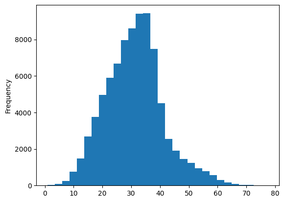

```python
obesity_df['Data_Value'].plot(kind='hist', bins = 30)
plt.show()
```

As we can see, it follows some what of a bell curve shape where the max percentage is 77.6% and the min is 0.9%. The highest frequency of values lies between the range of 30-35%.

To digress, let's take a look at the other data frames for cleaning and examination.

Let's look at ffr first

```python
display(ffr_df)
```

|  | address | city | country | keys | latitude | longitude | name | postalCode | province | websites |
| --- | --- | --- | --- | --- | --- | --- | --- | --- | --- | --- |
| 0 | 324 Main St | Massena | US | us/ny/massena/324mainst/-1161002137 | 44.921300 | -74.890210 | McDonald's | 13662 | NY | http://mcdonalds.com,http://www.mcdonalds.com/... |
| 1 | 530 Clinton Ave | Washington Court House | US | us/oh/washingtoncourthouse/530clintonave/-7914... | 39.532550 | -83.445260 | Wendy's | 43160 | OH | http://www.wendys.com |
| 2 | 408 Market Square Dr | Maysville | US | us/ky/maysville/408marketsquaredr/1051460804 | 38.627360 | -83.791410 | Frisch's Big Boy | 41056 | KY | http://www.frischs.com,https://www.frischs.com... |
| 3 | 6098 State Highway 37 | Massena | US | us/ny/massena/6098statehighway37/-1161002137 | 44.950080 | -74.845530 | McDonald's | 13662 | NY | http://mcdonalds.com,http://www.mcdonalds.com/... |
| 4 | 139 Columbus Rd | Athens | US | us/oh/athens/139columbusrd/990890980 | 39.351550 | -82.097280 | OMG! Rotisserie | 45701 | OH | http://www.omgrotisserie.com,http://omgrotisse... |
| ... | ... | ... | ... | ... | ... | ... | ... | ... | ... | ... |
| 9995 | 3013 Peach Orchard Rd | Augusta | US | us/ga/augusta/3013peachorchardrd/-791445730 | 33.415257 | -82.024531 | Wendy's | 30906 | GA | http://www.wendys.com,http://wendys.com |
| 9996 | 678 Northwest Hwy | Cary | US | us/il/cary/678northwesthwy/787691191 | 42.217300 | -88.255800 | Lee's Oriental Martial Arts | 60013 | IL | http://www.mcdonalds.com |
| 9997 | 1708 Main St | Longmont | US | us/co/longmont/1708mainst/-448666054 | 40.189190 | -105.101720 | Five Guys | 80501 | CO | http://fiveguys.com |
| 9998 | 67740 Highway 111 | Cathedral City | US | us/ca/cathedralcity/67740highway111/-981164808 | 33.788640 | -116.482150 | El Pollo Loco | 92234 | CA | http://www.elpolloloco.com,http://elpolloloco.com |
| 9999 | 5701 E La Palma Ave | Anaheim | US | us/ca/anaheim/5701elapalmaave/554191587 | 33.860074 | -117.789762 | Carl's Jr. | 92807 | CA | http://www.carlsjr.com |

10000 rows × 10 columns

We don't need the keys, postal code, and websites column. Also, the country column is irrelevant if all the rows describe a position in the US.

```python
ffr_df.drop(columns=['keys', 'websites', 'postalCode'])
# let's check if all the country values is US
ffr_df['country'].unique()
```

```
array(['US'], dtype=object)
```

Because we see that US is the only object we can drop that column. We understand that the data only describes data originating from the US.

```python
ffr_df.drop(columns=['keys', 'websites', 'country'])
```

|  | address | city | latitude | longitude | name | postalCode | province |
| --- | --- | --- | --- | --- | --- | --- | --- |
| 0 | 324 Main St | Massena | 44.921300 | -74.890210 | McDonald's | 13662 | NY |
| 1 | 530 Clinton Ave | Washington Court House | 39.532550 | -83.445260 | Wendy's | 43160 | OH |
| 2 | 408 Market Square Dr | Maysville | 38.627360 | -83.791410 | Frisch's Big Boy | 41056 | KY |
| 3 | 6098 State Highway 37 | Massena | 44.950080 | -74.845530 | McDonald's | 13662 | NY |
| 4 | 139 Columbus Rd | Athens | 39.351550 | -82.097280 | OMG! Rotisserie | 45701 | OH |
| ... | ... | ... | ... | ... | ... | ... | ... |
| 9995 | 3013 Peach Orchard Rd | Augusta | 33.415257 | -82.024531 | Wendy's | 30906 | GA |
| 9996 | 678 Northwest Hwy | Cary | 42.217300 | -88.255800 | Lee's Oriental Martial Arts | 60013 | IL |
| 9997 | 1708 Main St | Longmont | 40.189190 | -105.101720 | Five Guys | 80501 | CO |
| 9998 | 67740 Highway 111 | Cathedral City | 33.788640 | -116.482150 | El Pollo Loco | 92234 | CA |
| 9999 | 5701 E La Palma Ave | Anaheim | 33.860074 | -117.789762 | Carl's Jr. | 92807 | CA |

10000 rows × 7 columns

Now we can start hypothesis testing to find any co-variation and relationships between the features.

First, let's try to find the relationship between education level and obesity. Let's say that H0: The distribution of obesity among different levels of education are the same (education has no impact on obesity), and Ha: The distributions of obesity among different levels of education are different (education does have an impact on obesity).

Since we will be comparing two categorical types of data, we can use the Chi-Squared test. Below is the contingency table and a plot of the relationship:

```
level_of_obesity                  High   Low  Medium
Education
College graduate                   867  1173    1273
High school graduate               637   527    2149
Less than high school             1118   621    1574
Some college or technical school   613   855    1845
```

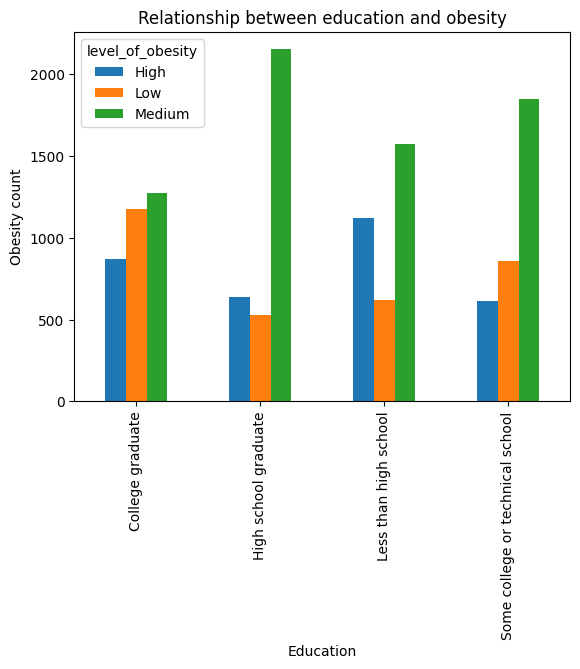

```python
import scipy.stats as st


def obesity_level(val):
  if val > 37:
    return 'High'
  elif 24.4 <= val <= 37:
    return 'Medium'
  else:
    return 'Low'

obesity_df['level_of_obesity'] = obesity_df['Data_Value'].apply(obesity_level)

new_obesity = obesity_df.dropna(subset = ['Education', 'Data_Value'])

contingency_table = pd.crosstab(new_obesity['Education'], new_obesity['level_of_obesity'])

print(contingency_table)

contingency_table.plot(kind = 'bar')

plt.title('Relationship between education and obesity')
plt.ylabel('Obesity count')

plt.show()
```

Now we can calculate the p-value using a Chi-Squared test and compare it to our significant value of 0.05. We can use this information to see whether we would need to reject the Null Hypothesis.

```python
res = st.chi2_contingency(contingency_table)

f"{res.pvalue:.162f}"
```

```
'0.000000000000000000000000000000000000000000000000000000000000000000000000000000000000000000000000000000000000000000000000000000000000000000000000000000000000000005'
```

Since we found our p-value to be 5.1 x 10^(-162), we can say that it is less than the significant value of 0.05. Since our p-value is less than 0.05, we can state that we reject the Null Hypothesis. Therefore, education does impact level of obesity because the different levels of education have different distributions of obesity.

We are going to observe the relation between number of fast food restaurants in a state to the obesity percentage of the state. First we need to filter the obesity dataframe to only include rows that is located in a USA state. After, we will filter it further to get only the most recent data on obesity percentages. Then we calculate the number of fast food restaurants per state by calculating how many times they appear in the ffr dataframe. Finally, we can merge the dataframes on the state column, and calculate the correlation using Pearson correlation coefficient.

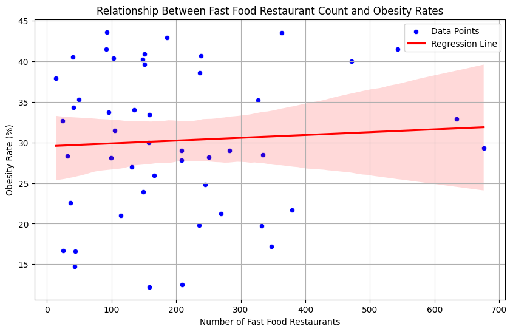

```python
import statsmodels.api as sm
import seaborn as sns

state_names = ['Alabama', 'Alaska', 'Arizona', 'Arkansas', 'California', 'Colorado', 'Connecticut',
               'Delaware', 'Florida', 'Georgia', 'Hawaii', 'Idaho', 'Illinois', 'Indiana', 'Iowa',
               'Kansas', 'Kentucky', 'Louisiana', 'Maine', 'Maryland', 'Massachusetts', 'Michigan',
               'Minnesota', 'Mississippi', 'Missouri', 'Montana', 'Nebraska', 'Nevada', 'New Hampshire',
               'New Jersey', 'New Mexico', 'New York', 'North Carolina', 'North Dakota', 'Ohio', 'Oklahoma',
               'Oregon', 'Pennsylvania', 'Rhode Island', 'South Carolina', 'South Dakota', 'Tennessee',
               'Texas', 'Utah', 'Vermont', 'Virginia', 'Washington', 'West Virginia', 'Wisconsin', 'Wyoming']

filtered_obesity_df = obesity_df[obesity_df['LocationDesc'].isin(state_names)]
most_recent_df = filtered_obesity_df.loc[filtered_obesity_df.groupby('LocationDesc')['YearEnd'].idxmax()]

ffr_df['province'].replace('Co Spgs', 'CO')
province_counts = ffr_df['province'].value_counts().reset_index()
province_counts.columns = ['LocationAbbr', 'count']

merged_df = pd.merge(province_counts, most_recent_df, on='LocationAbbr', how='inner')

X = merged_df['count']
y = merged_df['Data_Value']

X = sm.add_constant(X)

model = sm.OLS(y, X).fit()
plt.figure(figsize=(10, 6))

sns.scatterplot(data=merged_df, x='count', y='Data_Value', color='blue', label='Data Points')

sns.regplot(data=merged_df, x='count', y='Data_Value', scatter=False, color='red', label='Regression Line')

plt.title('Relationship Between Fast Food Restaurant Count and Obesity Rates')
plt.xlabel('Number of Fast Food Restaurants')
plt.ylabel('Obesity Rate (%)')
plt.legend()
plt.grid(True)
```

Let's try to find the relationship between income and obesity. Let's say that H0: The mean obesity rate is the same across every income group, and Ha: The mean obesity rate is not the same across every income group (that means at least one group would be different).

Since we are comparing multiple income groups and looking at differences among means, it is best to use ANOVA testing.

```python
income_df = obesity_df[['Income', 'Data_Value']].dropna()

g1 = income_df[income_df['Income'] == 'Less than $15,000']['Data_Value']
g2 = income_df[income_df['Income'] == '$15,000 - $24,999']['Data_Value']
g3 = income_df[income_df['Income'] == '$25,000 - $34,999']['Data_Value']
g4 = income_df[income_df['Income'] == '$35,000 - $49,999']['Data_Value']
g5 = income_df[income_df['Income'] == '$50,000 - $74,999']['Data_Value']
g6 = income_df[income_df['Income'] == '$75,000 or greater']['Data_Value']
g7 = income_df[income_df['Income'] == 'Data not reported']['Data_Value']

res = st.f_oneway(g1, g2, g3, g4, g5, g6, g7)

res.pvalue
```

```
1.027379650584492e-30
```

Since our p-value is 1.03 x 10^(-30), we can see that it is less than the significant value of 0.05, therefore we would reject the Null Hypothesis. Therefore, we can state that there is at least one group that's mean is different from the others.

We can display this down below:

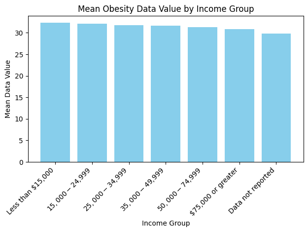

```python
import pandas as pd
import matplotlib.pyplot as plt

# Group the data based on Income categories and calculate their means
income_groups = [
    "Less than $15,000",
    "$15,000 - $24,999",
    "$25,000 - $34,999",
    "$35,000 - $49,999",
    "$50,000 - $74,999",
    "$75,000 or greater",
    "Data not reported"
]

mean_values = [
    g1.mean(),
    g2.mean(),
    g3.mean(),
    g4.mean(),
    g5.mean(),
    g6.mean(),
    g7.mean()
]

# Plot the means
plt.bar(income_groups, mean_values, color='skyblue')
plt.xlabel('Income Group')
plt.ylabel('Mean Data Value')
plt.title('Mean Obesity Data Value by Income Group')
plt.xticks(rotation=45, ha='right')
plt.tight_layout()
plt.show()
```

At first glance, our means are extremely similar, despite our results from ANOVA. However, this could imply that, despite the means are numerically close, the differences between each income's means are still statistically significant. Then, we can utilize a post-hoc test to test which income group is significantly different.

```
            Multiple Comparison of Means - Tukey HSD, FWER=0.05
============================================================================
      group1             group2       meandiff p-adj   lower   upper  reject
----------------------------------------------------------------------------
 $15,000 - $24,999  $25,000 - $34,999  -0.3854 0.6571 -1.0789  0.3081  False
 $15,000 - $24,999  $35,000 - $49,999  -0.5283 0.2709 -1.2218  0.1652  False
 $15,000 - $24,999  $50,000 - $74,999  -0.8289 0.0078 -1.5227 -0.1351   True
 $15,000 - $24,999 $75,000 or greater  -1.3017    0.0 -1.9952 -0.6082   True
 $15,000 - $24,999  Data not reported  -2.3067    0.0 -3.0002 -1.6132   True
 $15,000 - $24,999  Less than $15,000   0.1441 0.9964 -0.5494  0.8377  False
 $25,000 - $34,999  $35,000 - $49,999  -0.1429 0.9966 -0.8364  0.5506  False
 $25,000 - $34,999  $50,000 - $74,999  -0.4435 0.4904 -1.1373  0.2503  False
 $25,000 - $34,999 $75,000 or greater  -0.9163 0.0019 -1.6098 -0.2227   True
 $25,000 - $34,999  Data not reported  -1.9213    0.0 -2.6148 -1.2278   True
 $25,000 - $34,999  Less than $15,000   0.5296 0.2681  -0.164  1.2231  False
 $35,000 - $49,999  $50,000 - $74,999  -0.3006 0.8624 -0.9944  0.3932  False
 $35,000 - $49,999 $75,000 or greater  -0.7734 0.0175 -1.4669 -0.0799   True
 $35,000 - $49,999  Data not reported  -1.7784    0.0 -2.4719 -1.0849   True
 $35,000 - $49,999  Less than $15,000   0.6724 0.0644 -0.0211   1.366  False
 $50,000 - $74,999 $75,000 or greater  -0.4728 0.4086 -1.1666   0.221  False
 $50,000 - $74,999  Data not reported  -1.4778    0.0 -2.1716  -0.784   True
 $50,000 - $74,999  Less than $15,000    0.973 0.0007  0.2793  1.6668   True
$75,000 or greater  Data not reported   -1.005 0.0004 -1.6985 -0.3115   True
$75,000 or greater  Less than $15,000   1.4458    0.0  0.7523  2.1393   True
 Data not reported  Less than $15,000   2.4508    0.0  1.7573  3.1444   True
----------------------------------------------------------------------------
```

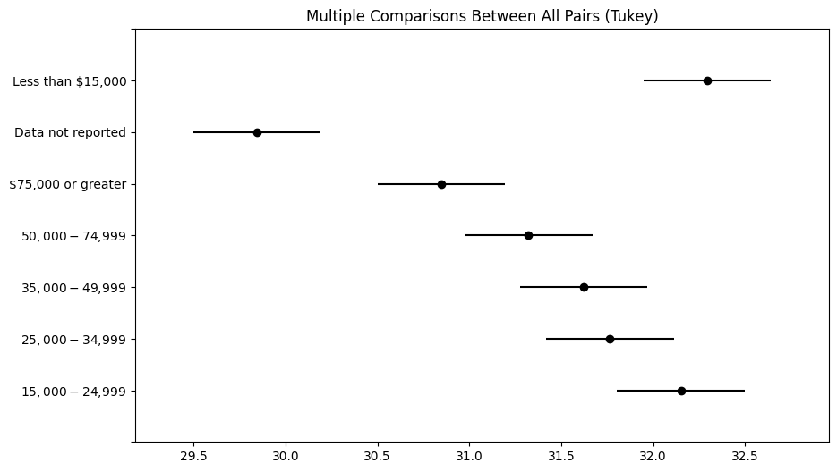

```python
from statsmodels.stats.multicomp import pairwise_tukeyhsd

tukey = pairwise_tukeyhsd(
    endog = income_df['Data_Value'],    # Dependent variable
    groups = income_df['Income'],  # Categorical group labels
    alpha = 0.05                          # Significance level
)

# Print the results
print(tukey)

# Optionally, plot the results
tukey.plot_simultaneous()
plt.show()
```

In comparison, the more moderate income ranges do not have significant differences from each other, implying that those with lower income are of higher significance toward influencing the percentage of obesity.

**ML Design/Development**

With these analyses, we are given an idea of the connection between the different features of the data sets and their correlation with obesity and inactivity. We can now transition to using ML for prediction and pattern detection. However, we need to manipulate our features as our data frame is currently unusable for ML applications. To start, we need to turn our data into numerical values, since every column is categorical. We can do this via assigning a number to each different category for each column. This is kind of a different variation of one hot encoding where we dont need to add a new column for every category. The columns that we will examine include the following: Education, Income, Age, Race, Data_Value, and location.

```python
# Education is first:
display(obesity_df['Education'].unique())
```

```
array([nan, 'High school graduate', 'Less than high school',
       'Some college or technical school', 'College graduate'],
      dtype=object)
```

```python
# assign each level of education a number from 1 to 4
education_dict = {'Less than high school': 1, 'High school graduate': 2, 'Some college or technical school': 3, 'College graduate':4}
obesity_df['Education'] = obesity_df['Education'].replace(education_dict)
display(obesity_df['Education'].unique())
```

```
array([nan,  2.,  1.,  3.,  4.])
```

```python
# Then income
display(obesity_df['Income'].unique())
```

```
array([nan, '$50,000 - $74,999', 'Data not reported', 'Less than $15,000',
       '$25,000 - $34,999', '$15,000 - $24,999', '$35,000 - $49,999',
       '$75,000 or greater'], dtype=object)
```

```python
# assign each level of income a number from 1 to 6 leaving 'Data not reported' to be converted to nan
income_dict = {'Less than $15,000':1, '$15,000 - $24,999':2, '$25,000 - $34,999':3, '$35,000 - $49,999':4, '$50,000 - $74,999':5, '$75,000 or greater':6}
obesity_df['Income'] = obesity_df['Income'].replace(income_dict)
display(obesity_df['Income'].unique())
obesity_df['Income'] = obesity_df['Income'].replace({'Data not reported': float('NaN')})
```

```
array([nan, 5, 'Data not reported', 1, 3, 2, 4, 6], dtype=object)
```

```python
# Age
display(obesity_df['Age(years)'].unique())
```

```
array([nan, '25 - 34', '55 - 64', '18 - 24', '45 - 54', '35 - 44',
       '65 or older'], dtype=object)
```

```python
# assign each level of age a number from 1 to 6
age_dict = {'18 - 24':1, '25 - 34':2, '35 - 44':3, '45 - 54':4, '55 - 64':5, '65 or older':6}
obesity_df['Age(years)'] = obesity_df['Age(years)'].replace(age_dict)
display(obesity_df['Age(years)'].unique())
```

```
array([nan,  2.,  5.,  1.,  4.,  3.,  6.])
```

```python
# Race/ethnicity
display(obesity_df['Race/Ethnicity'].unique())
```

```
array(['Hispanic', nan, 'American Indian/Alaska Native', 'Asian',
       'Non-Hispanic White', 'Other', '2 or more races',
       'Hawaiian/Pacific Islander', 'Non-Hispanic Black'], dtype=object)
```

```python
# assign each specified race a number from 1 to 8
race_dict = {'Non-Hispanic White':1, 'Non-Hispanic Black':2, 'Hispanic':3, 'Asian':4, 'American Indian/Alaska Native':5, 'Hawaiian/Pacific Islander':6, '2 or more races':7, 'Other':8}
obesity_df['Race/Ethnicity'] = obesity_df['Race/Ethnicity'].replace(race_dict)
display(obesity_df['Race/Ethnicity'].unique())
```

```
array([ 3., nan,  5.,  4.,  1.,  8.,  7.,  6.,  2.])
```

```python
# Class: Target Value for first Model
display(obesity_df['Class'].unique())
```

```
array(['Physical Activity', 'Obesity / Weight Status',
       'Fruits and Vegetables'], dtype=object)
```

```python
# assign each class a number from 1 to 3
class_dict = {'Obesity / Weight Status':1, 'Physical Activity':2, 'Fruits and Vegetables':3}
obesity_df['Class'] = obesity_df['Class'].replace(class_dict)
display(obesity_df['Class'].unique())
```

```
array([2, 1, 3])
```

With these columns now numerical, we need to find a way to fill in the missing values. Unfortunately, the dataset does not have a single row with no single missing value. However, we can see that the data has been sampled from multiple locations. We can use this to our advantage by filling in missing data in these locations with KNN imputation to replace missing data using similar datapoints. This is basically guessing what categories go in each column for a specific row, which may bias the data, but this is essential for doing any sort of ML algorithm.

To start, let's take a look at the quantity of entries in each location.

```python
obesity_df['LocationDesc'].value_counts()
```

| LocationDesc | count |
| --- | --- |
| National | 1736 |
| West Virginia | 1736 |
| Oklahoma | 1736 |
| Mississippi | 1736 |
| Oregon | 1736 |
| Wisconsin | 1736 |
| Kansas | 1736 |
| Florida | 1736 |
| Idaho | 1736 |
| Arizona | 1736 |
| Montana | 1736 |
| Georgia | 1736 |
| North Carolina | 1736 |
| Pennsylvania | 1736 |
| North Dakota | 1736 |
| South Carolina | 1736 |
| Nebraska | 1736 |
| Tennessee | 1736 |
| Missouri | 1736 |
| Nevada | 1736 |
| Iowa | 1736 |
| Indiana | 1736 |
| Ohio | 1736 |
| Alaska | 1736 |
| Vermont | 1736 |
| Colorado | 1736 |
| Kentucky | 1736 |
| Utah | 1736 |
| New York | 1736 |
| Wyoming | 1736 |
| District of Columbia | 1736 |
| Alabama | 1736 |
| Rhode Island | 1736 |
| Delaware | 1736 |
| Washington | 1736 |
| Maine | 1736 |
| Michigan | 1736 |
| Virginia | 1736 |
| California | 1736 |
| Texas | 1736 |
| Connecticut | 1736 |
| Massachusetts | 1736 |
| Arkansas | 1736 |
| Illinois | 1736 |
| New Hampshire | 1736 |
| New Mexico | 1736 |
| Maryland | 1736 |
| Minnesota | 1736 |
| Hawaii | 1736 |
| Louisiana | 1736 |
| South Dakota | 1736 |
| New Jersey | 1493 |
| Puerto Rico | 1316 |
| Guam | 1260 |
| Virgin Islands | 644 |

**dtype:** int64

let's group the data by these locations and show an example dataframe from one of those locations.

```python
features = obesity_df[['Education', 'Income', 'LocationDesc', 'Age(years)', 'Race/Ethnicity', 'Data_Value', 'Class']]
grouped_features = features.groupby('LocationDesc')
grouped_features.count()
display(grouped_features.get_group('Alabama'))
```

|  | Education | Income | LocationDesc | Age(years) | Race/Ethnicity | Data_Value | Class |
| --- | --- | --- | --- | --- | --- | --- | --- |
| 9 | NaN | NaN | Alabama | 2.0 | NaN | 35.2 | 1 |
| 48 | NaN | NaN | Alabama | 5.0 | NaN | 35.3 | 1 |
| 119 | NaN | NaN | Alabama | 3.0 | NaN | 31.9 | 1 |
| 236 | NaN | NaN | Alabama | NaN | NaN | 37.7 | 1 |
| 305 | NaN | NaN | Alabama | NaN | 6.0 | NaN | 1 |
| ... | ... | ... | ... | ... | ... | ... | ... |
| 88925 | NaN | NaN | Alabama | 2.0 | NaN | 21.2 | 2 |
| 88926 | NaN | NaN | Alabama | NaN | 7.0 | 24.9 | 2 |
| 88927 | NaN | 4.0 | Alabama | NaN | NaN | 34.7 | 1 |
| 88928 | NaN | NaN | Alabama | NaN | 8.0 | NaN | 2 |
| 88929 | NaN | NaN | Alabama | NaN | 6.0 | NaN | 1 |

1736 rows × 7 columns

Now, let's use Scikit to do KNN imputation.

```python
from sklearn.impute import KNNImputer

k = 3
imputer = KNNImputer(n_neighbors=k)
new_table = pd.DataFrame()
# knn imputation for each location
for loc in grouped_features.groups.keys():
  # make a new sub table with no missing values
  new_subtable = imputer.fit_transform(grouped_features.get_group(loc).drop(columns = ['LocationDesc']))

  new_subtable = pd.DataFrame(new_subtable, columns = grouped_features.get_group(loc).drop(columns = 'LocationDesc').columns)
  # append sub table to the new table
  new_table = pd.concat([new_table, new_subtable])

display(new_table)
```

|  | Education | Income | Age(years) | Race/Ethnicity | Data_Value | Class |
| --- | --- | --- | --- | --- | --- | --- |
| 0 | 2.666667 | 3.666667 | 2.000000 | 7.333333 | 35.200000 | 1.0 |
| 1 | 2.333333 | 4.666667 | 5.000000 | 7.333333 | 35.300000 | 1.0 |
| 2 | 3.000000 | 4.666667 | 3.000000 | 7.333333 | 31.900000 | 1.0 |
| 3 | 3.333333 | 4.666667 | 4.000000 | 7.333333 | 37.700000 | 1.0 |
| 4 | 2.333333 | 4.333333 | 3.333333 | 6.000000 | 34.133333 | 1.0 |
| ... | ... | ... | ... | ... | ... | ... |
| 1731 | 4.000000 | 1.000000 | 3.000000 | 3.666667 | 24.500000 | 1.0 |
| 1732 | 1.000000 | 1.333333 | 6.000000 | 6.666667 | 36.000000 | 2.0 |
| 1733 | 3.000000 | 3.666667 | 3.000000 | 3.666667 | 35.200000 | 1.0 |
| 1734 | 3.000000 | 4.000000 | 3.666667 | 3.666667 | 35.300000 | 1.0 |
| 1735 | 1.000000 | 5.666667 | 4.333333 | 3.666667 | 41.000000 | 1.0 |

93249 rows × 6 columns

We should also round the non integers to the nearest integers to match the categorical data.

```python
new_table['Education'] = new_table['Education'].apply(lambda x: round(x))
new_table['Income'] = new_table['Income'].apply(lambda x: round(x))
new_table['Age(years)'] = new_table['Age(years)'].apply(lambda x: round(x))
new_table['Race/Ethnicity'] = new_table['Race/Ethnicity'].apply(lambda x: round(x))
display(new_table)
```

|  | Education | Income | Age(years) | Race/Ethnicity | Data_Value | Class |
| --- | --- | --- | --- | --- | --- | --- |
| 0 | 3 | 4 | 2 | 7 | 35.200000 | 1.0 |
| 1 | 2 | 5 | 5 | 7 | 35.300000 | 1.0 |
| 2 | 3 | 5 | 3 | 7 | 31.900000 | 1.0 |
| 3 | 3 | 5 | 4 | 7 | 37.700000 | 1.0 |
| 4 | 2 | 4 | 3 | 6 | 34.133333 | 1.0 |
| ... | ... | ... | ... | ... | ... | ... |
| 1731 | 4 | 1 | 3 | 4 | 24.500000 | 1.0 |
| 1732 | 1 | 1 | 6 | 7 | 36.000000 | 2.0 |
| 1733 | 3 | 4 | 3 | 4 | 35.200000 | 1.0 |
| 1734 | 3 | 4 | 4 | 4 | 35.300000 | 1.0 |
| 1735 | 1 | 6 | 4 | 4 | 41.000000 | 1.0 |

93249 rows × 6 columns

Now that we have our data ready for processing, we can take a moment to consider an important observation. The class data value describes the level of obesity, activity, or fruit/vegetable consumption. We can look at what exactly each data value describes via the question column.

```python
display(obesity_df['Class'].value_counts())
display(obesity_df['Question'].value_counts())
```

| Class | count |
| --- | --- |
| 2 | 47885 |
| 1 | 36234 |
| 3 | 9130 |

**dtype:** int64

| Question | count |
| --- | --- |
| Percent of adults aged 18 years and older who have obesity | 18117 |
| Percent of adults aged 18 years and older who have an overweight classification | 18117 |
| Percent of adults who engage in no leisure-time physical activity | 18089 |
| Percent of adults who achieve at least 300 minutes a week of moderate-intensity aerobic physical activity or 150 minutes a week of vigorous-intensity aerobic activity (or an equivalent combination) | 7449 |
| Percent of adults who achieve at least 150 minutes a week of moderate-intensity aerobic physical activity or 75 minutes a week of vigorous-intensity aerobic physical activity and engage in muscle-stre… | 7449 |
| Percent of adults who achieve at least 150 minutes a week of moderate-intensity aerobic physical activity or 75 minutes a week of vigorous-intensity aerobic activity (or an equivalent combination) | 7449 |
| Percent of adults who engage in muscle-strengthening activities on 2 or more days a week | 7449 |
| Percent of adults who report consuming fruit less than one time daily | 4565 |
| Percent of adults who report consuming vegetables less than one time daily | 4565 |

**dtype:** int64

We can group these questions into the three categories of obesity, activity, and fruit/vegetable consumption.

**Obesity (1):**

*Negative:* Percent of adults aged 18 years and older who have obesity; Percent of adults aged 18 years and older who have an overweight classification

**Activity (2):**

*Negative:* Percent of adults who engage in no leisure-time physical activity;

*Positive:* Percent of adults who achieve at least 300 minutes a week of moderate-intensity...; Percent of adults who achieve at least 150 minutes a week of moderate-intensity...; Percent of adults who achieve at least 150 minutes a week of moderate-intensity aerobic physical activity or 75 minutes a week of vigorous-intensity aerobic activity (or an equivalent combination); Percent of adults who engage in muscle-strengthening activities on 2 or more days a week;

**Fruit/Vegetable consumption (3):**

*Negative:* Percent of adults who report consuming fruit less than one time daily Percent of adults who report consuming vegetables less than one time daily

**Overall Idea**

A higher data value for the topic like obesity indicates a negative conclusion.

A higher data value for activity in terms of no leisure time physical activity indiciates a negative conclusion, whereas a higher value for the rest is positive.

Finally, A higher data value for fruit/vegetable consumption indicates a negative conclusion.

These ideas are important for regressors. In the following code, we explore the accuracy of different models in predicting the percentage of obesity given a description of a population (Race, Age range, Education, and Income).

For each different category, we can make a linear regression model for predicting the percentage for that category.

**ML Algorithm Training and Test Data Analysis**

```python
display(new_table)
```

|  | Education | Income | Age(years) | Race/Ethnicity | Data_Value | Class |
| --- | --- | --- | --- | --- | --- | --- |
| 0 | 3 | 4 | 2 | 7 | 35.200000 | 1.0 |
| 1 | 2 | 5 | 5 | 7 | 35.300000 | 1.0 |
| 2 | 3 | 5 | 3 | 7 | 31.900000 | 1.0 |
| 3 | 3 | 5 | 4 | 7 | 37.700000 | 1.0 |
| 4 | 2 | 4 | 3 | 6 | 34.133333 | 1.0 |
| ... | ... | ... | ... | ... | ... | ... |
| 1731 | 4 | 1 | 3 | 4 | 24.500000 | 1.0 |
| 1732 | 1 | 1 | 6 | 7 | 36.000000 | 2.0 |
| 1733 | 3 | 4 | 3 | 4 | 35.200000 | 1.0 |
| 1734 | 3 | 4 | 4 | 4 | 35.300000 | 1.0 |
| 1735 | 1 | 6 | 4 | 4 | 41.000000 | 1.0 |

93249 rows × 6 columns

```
Mean Squared Error for Obesity: 28.361608311875717
R-squared: 0.2556615957364562
```

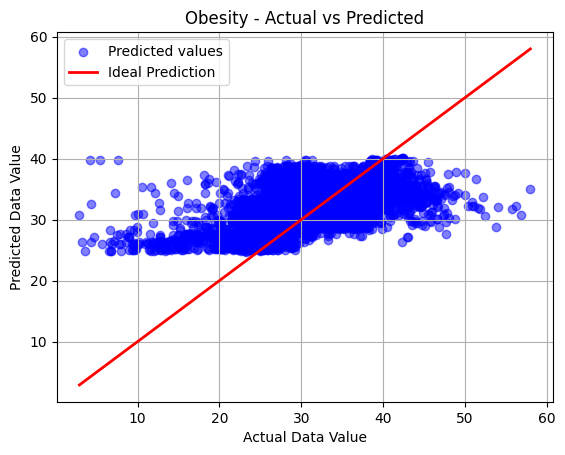

```
Mean Squared Error for Activity: 129.32780845095235
R-squared: 0.007346128474098879
```

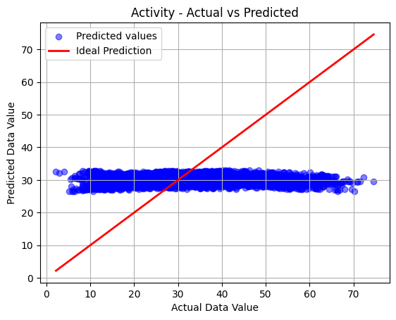

```
Mean Squared Error for Nutrition: 102.35161305502322
R-squared: 0.1852917167638467
```

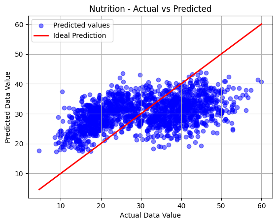

```python
from sklearn.model_selection import train_test_split
from sklearn.linear_model import LinearRegression
from sklearn.metrics import mean_squared_error, r2_score
from sklearn.preprocessing import StandardScaler

obesity = new_table[new_table['Class'] == 1]
activity = new_table[new_table['Class'] == 2]
nutrition = new_table[new_table['Class'] == 3]

dfs = [("Obesity",obesity), ("Activity",activity), ("Nutrition",nutrition)]

for group_name, df in dfs:
  target_features = df[['Education', 'Income', 'Age(years)', 'Race/Ethnicity']]
  model_target = df['Data_Value']
  X_train, X_test, y_train, y_test = train_test_split(target_features, model_target, test_size = 0.2, random_state = 42)
  scaler = StandardScaler()
  X_train_scaled = scaler.fit_transform(X_train)
  X_test_scaled = scaler.transform(X_test)
  model = LinearRegression()
  model.fit(X_train_scaled, y_train)
  y_pred = model.predict(X_test_scaled)
  mse = mean_squared_error(y_test, y_pred)
  r2 = r2_score(y_test, y_pred)
  print(f"Mean Squared Error for {group_name}: {mse}")
  print(f"R-squared: {r2}")

  plt.scatter(y_test, y_pred, color='blue', alpha=0.5, label = "Predicted values")
  plt.plot([min(y_test), max(y_test)], [min(y_test), max(y_test)], color='red', linewidth=2, label = "Ideal Prediction")
  plt.title(f"{group_name} - Actual vs Predicted")
  plt.xlabel('Actual Data Value')
  plt.ylabel('Predicted Data Value')
  plt.grid(True)
  plt.legend()
  plt.show()
```

From the start, we prioritized focusing on obesity as the primary target variable in the dataset, which includes multiple classes such as activity and nutrition as shown in the visualizations above. Given this initial focus, we chose to move forward with obesity as it aligns with the project's objectives. Thus, while other classes like activity and nutrition were considered, the decision to move forward with obesity is based on the project's initial goal.

```
Mean Squared Error for Obesity: 28.361608311875717
R-squared: 0.2556615957364562
```

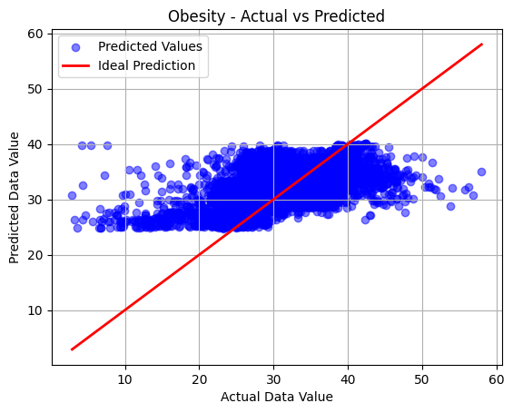

```python
target_features = obesity[['Education', 'Income', 'Age(years)', 'Race/Ethnicity']]
model_target = obesity['Data_Value']
X_train, X_test, y_train, y_test = train_test_split(target_features, model_target, test_size = 0.2, random_state = 42)
scaler = StandardScaler()
X_train_scaled = scaler.fit_transform(X_train)
X_test_scaled = scaler.transform(X_test)
model = LinearRegression()
model.fit(X_train_scaled, y_train)
y_pred = model.predict(X_test_scaled)
mse = mean_squared_error(y_test, y_pred)
r2 = r2_score(y_test, y_pred)
print(f"Mean Squared Error for Obesity: {mse}")
print(f"R-squared: {r2}")
plt.scatter(y_test, y_pred, color='blue', alpha=0.5, label = "Predicted Values")
plt.plot([min(y_test), max(y_test)], [min(y_test), max(y_test)], color='red', linewidth=2, label = "Ideal Prediction")
plt.title(f"Obesity - Actual vs Predicted")
plt.xlabel('Actual Data Value')
plt.ylabel('Predicted Data Value')
plt.grid(True)
plt.legend()
plt.show()
```

The Mean Squared Error (MSE) for obesity using linear regression is approximately 28.362. MSE measures the average squared difference between the predicted and actual values. In this case, an MSE of 28.362 means that, on average, the squared difference between the predicted and actual values is 28.362. A lower MSE indicates a better fit, so while this value isn’t ideal, it provides a starting point for evaluation. As this is the first model we have tested, the result suggests that the model is reasonably performing but may not be the most optimal.

Our R-squared value using linear regression is 0.256, which means that about 25.6% of the variance in the obesity data is explained by the model. R-squared can range from -1 to 1. A value of 1 would indicate that the model perfectly explains the variance in the target variable, while a value of 0 means that the model does not improve on simply predicting the mean of the target variable. A negative R-squared indicates that the model performs worse than predicting the mean.

```python
from sklearn.neighbors import KNeighborsRegressor
from sklearn.tree import DecisionTreeRegressor
from sklearn.ensemble import RandomForestRegressor
from sklearn.preprocessing import PolynomialFeatures
from sklearn.linear_model import LinearRegression
from sklearn.ensemble import GradientBoostingRegressor
from sklearn.pipeline import make_pipeline

models = {
    'Polynomial': make_pipeline(PolynomialFeatures(7), LinearRegression()),
    'KNN': KNeighborsRegressor(n_neighbors=20),
    'Decision Tree': DecisionTreeRegressor(random_state=42),
    'Random Forest': RandomForestRegressor(random_state=42),
    'Gradient Boosting': GradientBoostingRegressor(random_state=42),
    'Linear Regression': LinearRegression()
}
```

```
Mean Squared Error for Polynomial: 22.50360691296797
R-squared: 0.4094023626735278
```

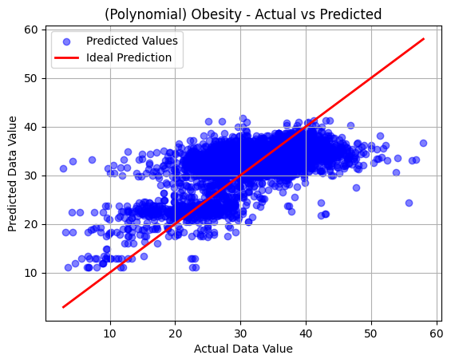

```
Mean Squared Error for KNN: 23.434549173987705
R-squared: 0.3849701771144749
```

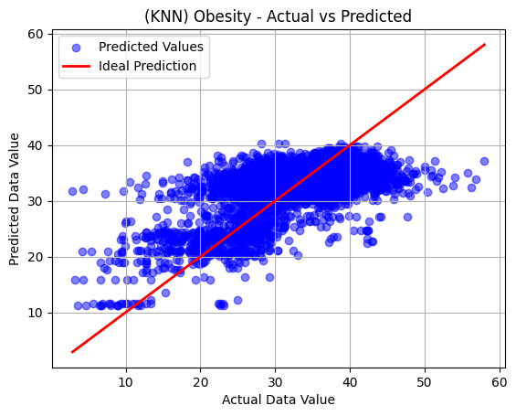

```
Mean Squared Error for Decision Tree: 22.36625415404215
R-squared: 0.4130071276881139
```

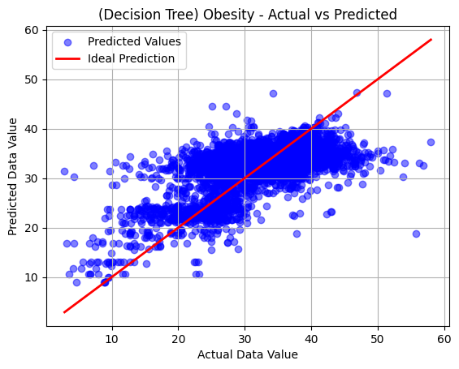

```
Mean Squared Error for Random Forest: 22.248140042551135
R-squared: 0.41610698254477285
```

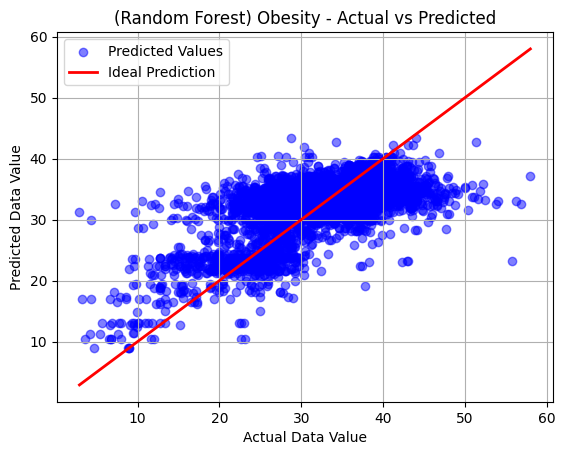

```
Mean Squared Error for Gradient Boosting: 22.79475606241995
R-squared: 0.40176127649383364
```

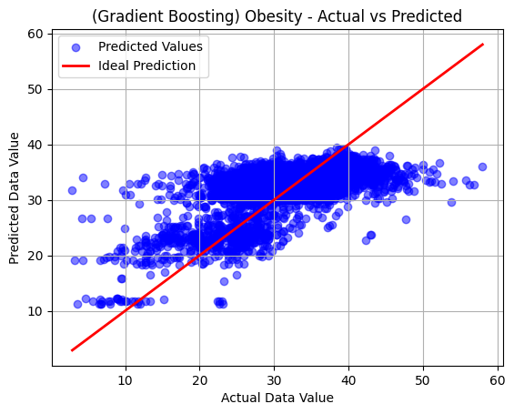

```
Mean Squared Error for Linear Regression: 28.361608311875717
R-squared: 0.2556615957364562
```

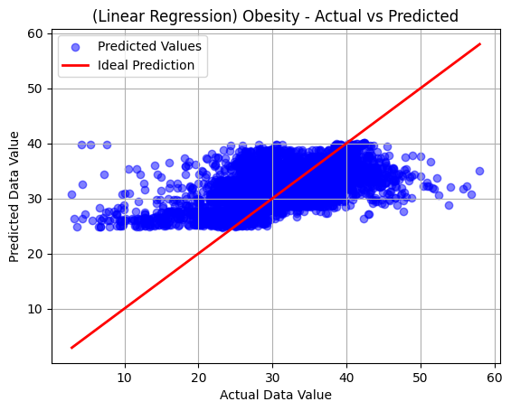

```python
for model_name, model in models.items():
    model = model
    model.fit(X_train_scaled, y_train)
    y_pred = model.predict(X_test_scaled)
    mse = mean_squared_error(y_test, y_pred)
    r2 = r2_score(y_test, y_pred)
    print(f"Mean Squared Error for {model_name}: {mse}")
    print(f"R-squared: {r2}")

    plt.scatter(y_test, y_pred, color='blue', alpha=0.5, label = "Predicted Values")
    plt.plot([min(y_test), max(y_test)], [min(y_test), max(y_test)], color='red', linewidth=2, label = "Ideal Prediction")
    plt.title(f"({model_name}) Obesity - Actual vs Predicted")
    plt.xlabel('Actual Data Value')
    plt.ylabel('Predicted Data Value')
    plt.grid(True)
    plt.legend()
    plt.show()
```

The red lines in the graph represent the ideal distribution of the predicted values. If the predicted values were all neatly placed upon this line, the accuracy of the model would be perfect.

**Insights and Conclusion**

Throughout the tutorial, we have gained a fair amount of knowldege regarding using the data gathered for prediction of a population's level of obesity given its features. For example, if we are looking at a population of people who are hispanic, 18-24 years old, have a college education, and high income, we can assess their level of obesity.

```python
race_val = race_dict['Hispanic']
age_val = age_dict['18 - 24']
income_val = income_dict['$75,000 or greater']
education_val = education_dict['College graduate']
obesity_percentage = models['Random Forest'].predict([[education_val, income_val, age_val, race_val]])
print(obesity_percentage)
```

```
[18.20874881]
```

This prediction is the estimated percentage of obesity within the population described by the given categories.